# Øvelse i univariat analyse: fangstbeviser

## 1. Hent og indlæs data

I denne øvelser skal du lave lidt indledende deskriptiv statistik for at beskrive udviklingen i antal fangstbeviser fra 1993 til 2022. Mere konkret skal du bruge de værktøjer, som du har lært om i univariat analyse. Start med at hente datasættet “Fangstbeviser.dta” fra lectio. Gem det i samme mappe som dit R-project. Du kan også oprette en mappe i folderen med dit project, der hedder “Data”. Læg mærke til at filen har formatet “.dta”. Derfor skal du indlæse pakken *haven* for at indlæse datasættet. Dereftre skal du bruge funktionen `read_dta()` til at indlæse datasættet og gemme det i et objekt, der f.eks. kunne hedde “df”:

```r
library(haven)

df <- read_dta("Data/Fangstbeviser.dta")
```

- Start med at dan dig et overblik over datasættet. Hvor mange variable indeholder det, og hvad hedder de? Brug evt. funktionen `names` til at liste variablenes navne:

```r
library(janitor)

names(df)
```

```
## [1] "type"          "tid"           "fangstbeviser"
```

- Undersøg nu hvilken type variablerne er ved at bruge funktionen `class()`. Hvilket måleniveau har hver af variablene?

Variablen *fangstbeviser* viser antallet af fangstbeviser hvert år. Variablen *type* indikerer, at der er tale om erhvervsfangstbeviser, og variablen *tid* viser hvilket år, der er tale om.

## 2. Lav en akkumuleret frekvenstabel

- Start med at undersøg datasættet. Det er faktisk allerede sorteret som en frekvenstabel. Hvad viser tabellen?

```r
# Her starter vi med datasættet, som vi sender videre over i select funktionen, hvor vi udvælger de variable, som vi gerne vil se. De tre variable, sender vi over i funktionen "view", som viser os datasættet.

df %>% select(tid, fangstbeviser) %>% View()
```

- Brug nu funktionen `cumsum()` til at lave en variabel, der giver den akkumulerede frekvens. Kald variablen “fangstbeviser_akkum”

```r
# Her tilføjer vi en ny variabel "akkum" til datasættet "df". Funktionen cumsum laver en akkumuleret variabel over variablen fangstbeviser over tid.
df$fangstbeviser_akkum <- cumsum(df$fangstbeviser)

# Se nu variablen i datasettet
df %>% select(tid, fangstbeviser, fangstbeviser_akkum) %>% View()
```

- Hvad fortæller den akkumulerede variabel?

## 3. Skab overblik over tabellen med visualiseringer

Tabellen er ganske lang over derfor også uoverskuelig. Det er nemmere at danne sig et overblik over udviklingen i fangstbeviser over tid med en figur. Brug ggplot til at lave et søjlediagram over antallet af fangerbeviser over tid. Du skal specificere:

- variablen på x-aksen
- variablen på y-aksen
- hvilken “statistik” grafen skal vise. For at få frekvenser, skal du vælge “identity”, da det fortæller ggplot, at grafen skal vise nøjagtig de værdier, som er i variablen i datasættet.

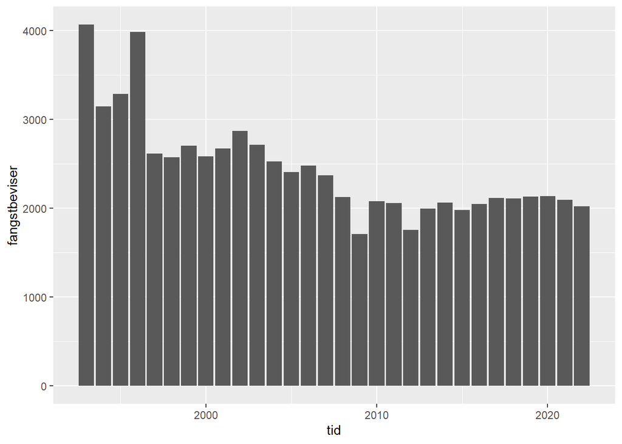

```r
ggplot(df, aes(x = tid, y = fangstbeviser)) + # specificer datasæt samt x og y variabler
  geom_bar(stat = "identity") # Brug geom_bar til at lave et søjediagram
```

- Kan du gøre plottet endnu flottere? Prøv at tilføj en titel til figuren og titler til akserne via `labs()` funktionen, som står for “labels” eller “mærkater”.

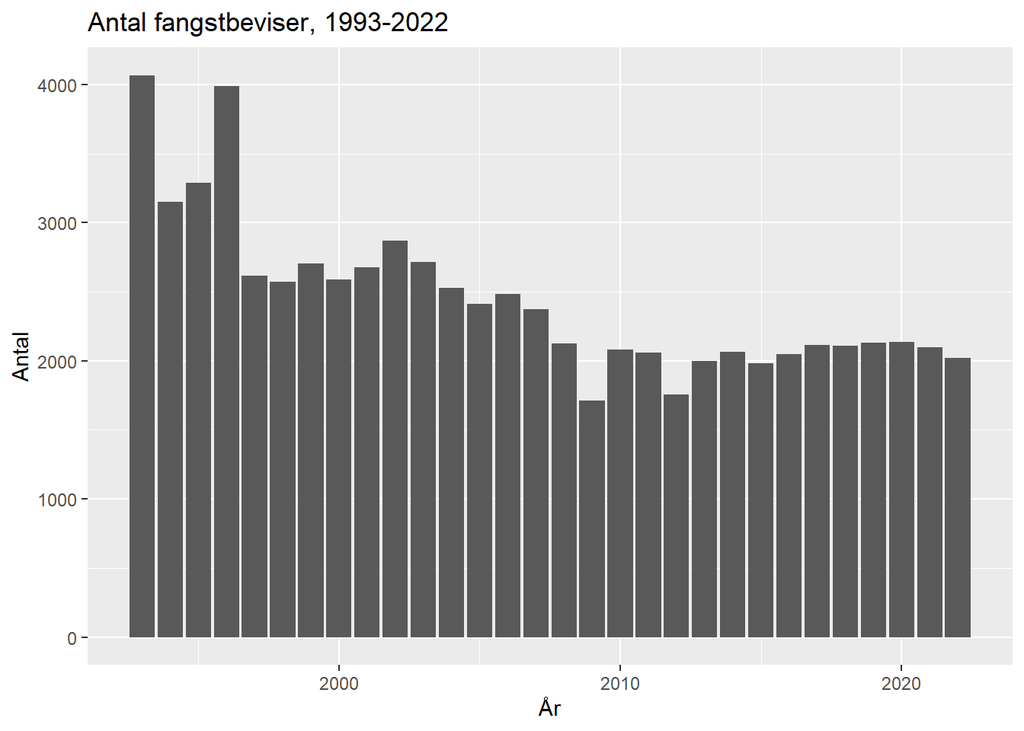

```r
ggplot(df, aes(x = tid, y = fangstbeviser)) +
  geom_bar(stat = "identity") +  # Brug geom_bar til at lave et søjediagram
  labs(title = "Antal fangstbeviser, 1993-2022",  # tilføj en titel
       x = "År", # tilføj titel til x-aksen
       y = "Antal") # tilføj titel til y-aksen
```

- Du kan evt. tilføje nedenstående for at centrere titlen via `theme()`:

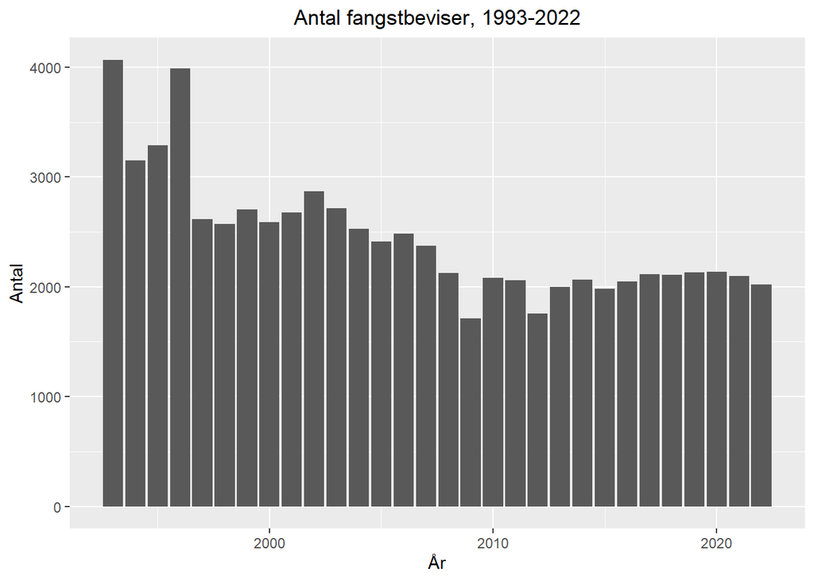

```r
ggplot(df, aes(x = tid, y = fangstbeviser)) +
  geom_bar(stat = "identity") +  # Brug geom_bar til at lave et søjediagram
  labs(title = "Antal fangstbeviser, 1993-2022",  # tilføj en titel
       x = "År", # tilføj titel til x-aksen
       y = "Antal") + # tilføj titel til y-aksen
  theme(plot.title = element_text(hjust = 0.5)) # Centrerer titlen
```

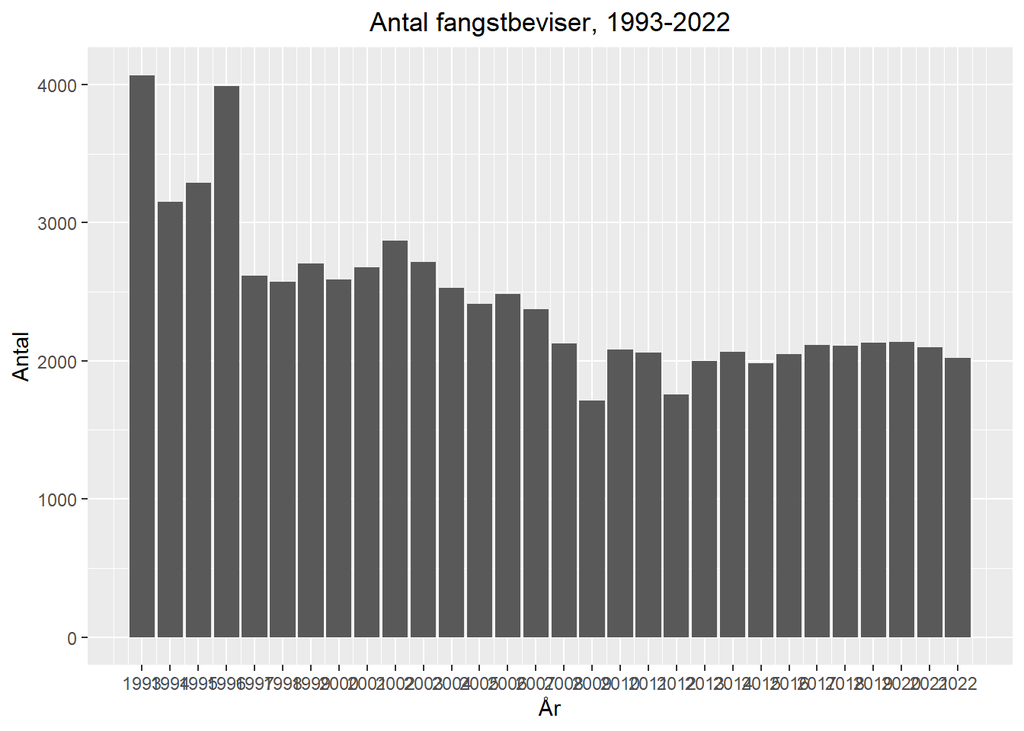

```r
ggplot(df, aes(x = tid, y = fangstbeviser)) +
  geom_bar(stat = "identity") +  # Brug geom_bar til at lave et søjediagram
  labs(title = "Antal fangstbeviser, 1993-2022",  # tilføj en titel
       x = "År", # tilføj titel til x-aksen
       y = "Antal") + # tilføj titel til y-aksen
    scale_x_continuous(breaks = unique(df$tid)) + # Denne linje specificerer, at der skal være lige så mange "labels" på xaksen skal være, som der er værdier på variablen "tid".
  theme(plot.title = element_text(hjust = 0.5)) # Centrerer titlen
```

- Fordi der er så mange labels på x-aksen nu, ligger de oveni hinanden. Tilføj `axis.text.x = element_text(angle = 90, hjust = 1` under `theme()` for at rotere labels 90 grader.

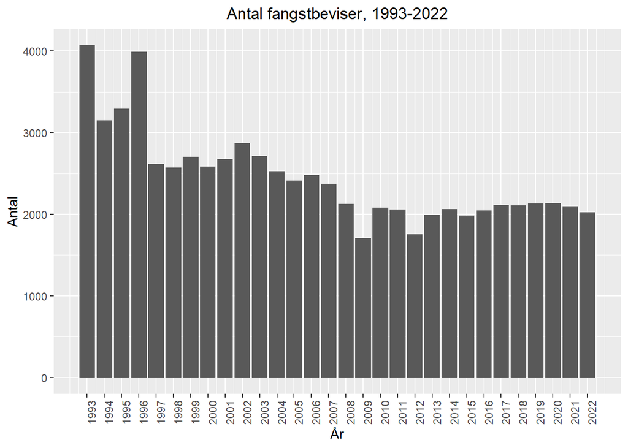

```r
ggplot(df, aes(x = tid, y = fangstbeviser)) +
  geom_bar(stat = "identity") +  # Use geom_bar for bar plot
  labs(title = "Antal fangstbeviser, 1993-2022",
       x = "År",
       y = "Antal") +
  scale_x_continuous(breaks = unique(df$tid)) + # Denne linje specificerer, at der skal være lige så mange "labels" på xaksen skal være, som der er værdier på variablen "tid".
  theme(axis.text.x = element_text(angle = 90, hjust = 1), # Vender labels på x aksen 90 grader
        plot.title = element_text(hjust = 0.5)) # Centrerer titlen
```

- Vælg som det sidste en flot farve til dit plot. Tilføj f.eks. farven blå ved at skrive `fill = "blue"` efter `stat` i `geom_bar()` funktionen.

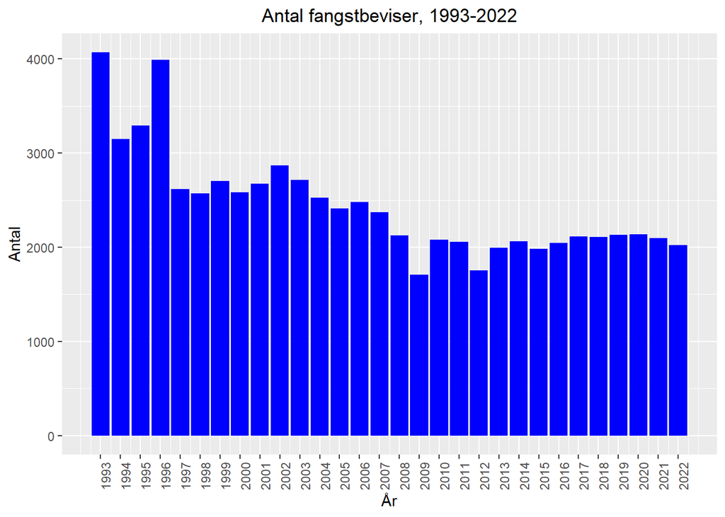

```r
ggplot(df, aes(x = tid, y = fangstbeviser)) +
  geom_bar(stat = "identity", fill = "blue") +  # Use geom_bar for bar plot
  labs(title = "Antal fangstbeviser, 1993-2022",
       x = "År",
       y = "Antal") +
  scale_x_continuous(breaks = unique(df$tid)) + # Denne linje specificerer, at der skal være lige så mange "labels" på xaksen skal være, som der er værdier på variablen "tid".
  theme(axis.text.x = element_text(angle = 90, hjust = 1), # Vender labels på x aksen 90 grader
        plot.title = element_text(hjust = 0.5)) # Centrerer titlen
```

- Hvad viser dit plot? Hvordan har antallet af fangstbeviser udviklet sig de seneste 30 år?

## 4. Centrummål

Søjlediagrammet viser fordelingen af fangstbeviser over tid. Men hvad hvis du gerne vil vide, hvor mange fangstbeviser der typisk er per år? Det er det, vi bruger centrummål til.

- Brug funktionen `summary` til at at give dig gennemsnit, median og kvartiler for variablen fangstbeviser:

```r
summary(df$fangstbeviser)
```

[output not shown]

- Hvad er gennemsnittet på variablen?
- Hvad er medianen på variablen?
- Hvad betyder det, at de ikke er helt ens?

`summary()` giver dig også minimumsværdien og maksimumsværdien samt første og tredje kvartil. Disse værdier kan nemt visualiseres i et boxplot med ggplot:

```r
ggplot(df) +
  geom_boxplot(aes(y = fangstbeviser)) +
  scale_x_discrete( ) +
  labs(title = "Fangstbeviser",
       y = "Antal") +
  theme(plot.title = element_text(hjust = 0.5)) + # Centrerer titlen
   ylim(c(1500, 4500)) + # Specificerer hvor y-aksen stopper og slutter
  scale_y_continuous(breaks = seq(1500, 5000, by = 500)) # Labels på y-aksen skal starte på 1500, slutte på 5000 og have 500 imellem for hver label
```

[output not shown]

- Hvor er minimumsværdien og maksimumsværdien at finde på boxplottet?
- Hvor er medianen?
- Hvor er først og tredje kvartil?
- Hvad fortæller kvartilerne os om fordelingen på antallet af fangstbeviser?

## 5. Varians og standardafvigelse

Udreng nu variablens varians og standardafvigelse. Brug funktionerne `var()` og `sd()`:

```r
# Varians

var(df$fangstbeviser)


# Standardafvigelse

sd(df$fangstbeviser)
```

[output not shown]

- Hvad fortæller henholdsvis varians og standardafvigelse?
- Hvis du skulle forklare en arbejdsgiver, hvor meget variation der har været i antallet af fangstbeviser over de senest30 år, hvilket mål ville du så finde mest anvendeligt?

## 6. Konfidensintervaller

Som det sidste skal du udregne konfidensintervallet for det gennemsnitlige antal fangstbeviser i perioden. Brug funktionen `t.test()`:

```r
t.test(df$fangstbeviser)
```

[output not shown]

- Forklar hvilken information dine konfidensintervaller giver. Hvad er fordelen ved at udregne konfidensintervaller, når du rapporterer gennemsnit?